# 01_Mental models

```python
%pylab inline
```

## Today

- List comprehensions
- Mental models (math fundamentals)
- Algorithm analysis
- Big-O notation

## Modifying a list

```python
my_list = [1, 3, 5, 7, 9]
```

```python
new_list = []
for element in my_list:
    new_element = element + 1
    new_list.append(new_element)
```

```python
print(new_list)
```

```
[2, 4, 6, 8, 10]
```

```python
my_list = [1, 3, 5, 7, 9]
new_list = []
for element in my_list:
    new_element = element * 2
    new_list.append(new_element)
print(new_list)
```

```
[2, 6, 10, 14, 18]
```

What is the difference between these two programs?

```
my_list = [1, 3, 5, 7, 9]
new_list = []
for element in my_list:
    new_element = element + 1
    new_list.append(new_element)
```

```
my_list = [1, 3, 5, 7, 9]
new_list = []
for element in my_list:
    new_element = element * 2
    new_list.append(new_element)
```

## Introducing list comprehensions

In pseudo-code we want something like:

```
# For every element in a list:
#     Perform some operation on the element
# Give me a new list
```

```
# Perform operation on x every time we have an x in a list
```

```
# Perform operation on x for x in my_list
```

```
# x + 1 for x in my_list
```

```python
my_list = [1, 3, 5, 7, 9]
new_list = []
for x in my_list:
    new_element = x + 1
    new_list.append(new_element)
```

```python
my_list = [1, 3, 5, 7, 9]
new_list = [x + 1 for x in my_list]
```

```python
print(new_list)
```

```
[2, 4, 6, 8, 10]
```

```python
my_list = [1, 3, 5, 7, 9]
new_list = [x ** 2 for x in my_list]
print(new_list)
```

```
[1, 9, 25, 49, 81]
```

## List comprehension exercise:

This is the pseudo-code:

```
# x + 1 for x in my_list
```

Using the list `[1, 3, 5, 7, 9]`, do the following:

- Increase all elements by 3
- Subtract 10 from all elements
- Multiply all elements by themselves

## Understanding the world through models

- The world is complex
  - We can never understand all of it
- ... So we think in models
  - "I heard that americans are stupid, therefore all americans I meet are stupid"
- Machines do this too:
  - ["... algorithms are ... wholly dependent on the data it is given"](https://medium.com/codait/cognitive-bias-in-machine-learning-d287838eeb4b)
  - Pretty dangerous in [for instance criminal prediction models](https://www.propublica.org/article/machine-bias-risk-assessments-in-criminal-sentencing)

## No models are true

- ... but some are useful

[figure not shown]

## Linear $f(x) = x$

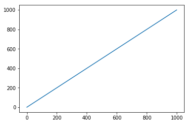

```python
import matplotlib.pyplot as plt


xs = range(0, 1000)
ys = [x for x in xs]
plt.plot(xs, ys)
```

- Running time -> calories burned
- Fuel in car -> distance it can drive

## Quadratic $f(x) = x^2$

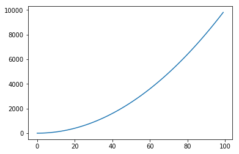

```python
xs = range(0, 100)
ys = [x * x  for x in xs]
plt.plot(xs, ys)
```

- Heat -> Ice cream sales
- Size of a square -> area

## Exponential $f(x) = 2^x$

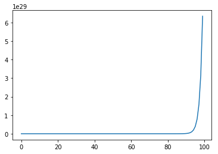

```python
xs = range(0, 100)
ys = [2 ** x for x in xs]
plt.plot(xs, ys)
```

- Loans work like this (compound interest: $P e ^ {rt}$)
- Radioactive decay ($Ne^{−t/τ}$)
- Population growth

## Logarithmic $f(x) = log_2(x)$

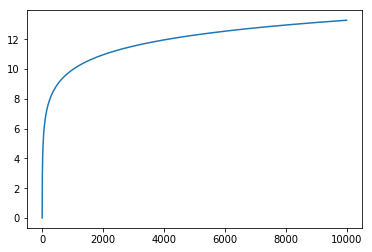

```python
import math


xs = range(1, 10000)
ys = [math.log2(x) for x in xs]
plt.plot(xs, ys)
```

- Money -> Happiness
- Decibel and richter scale

## Logartihm examples

```python
import math
```

```python
print(math.log10(1))
```

```
0.0
```

```python
print(math.log10(10))
```

```
1.0
```

```python
print(math.log10(100))
```

```
2.0
```

```python
print(math.log10(1000))
```

```
3.0
```

```python
print(math.log10(20))
```

[output not shown]

## Log$_2$

```python
print(math.log2(1))
```

```
0.0
```

```python
print(math.log2(2))
```

```
1.0
```

```python
print(math.log2(4))
```

```
2.0
```

```python
print(math.log2(8))
```

```
3.0
```

```python
print(math.log2(16))
```

```
4.0
```

```python
print(math.log2(3))
```

```
1.584962500721156
```

## Logarithm definition

Answers: What is the exponent $m$ that I need to raise the base $b$ with to get $x$?

- $b^m = x$

Question: What is the exponent $m$ that I need to raise the base 10 with to get 100?

Answer: $10^m = 100$

```python
math.log10(100)
```

Question: What is the exponent $m$ that I need to raise the base $2$ with to get $4$?

Answer: $2^m = 4$

```python
math.log2(4)
```

```python
2 ** 2
```

## Order of growth

Given 1 increase in input, how much output do we get?

- Linear: $f(x) = x$

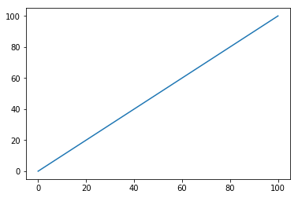

```python
import matplotlib.pyplot as plt


xs = [0, 100]
ys = [0, 100]
plt.plot(xs, ys)
```

- Quadratic: $f(x) = x^2$

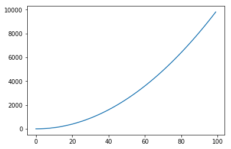

```python
xs = range(0, 100)
ys = [x * x for x in xs]
plt.plot(xs, ys)
```

- Exponential: $f(x) = 2^x$

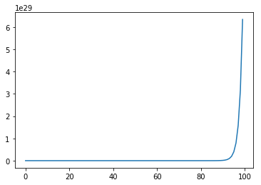

```python
xs = range(0, 100)
ys = [2 ** x for x in xs]
plt.plot(xs, ys)
```

- Logarithm: $f(x) = log_2(x)$

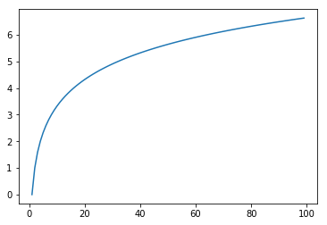

```python
import math


xs = range(1, 100)
ys = [math.log2(x) for x in xs]
plt.plot(xs, ys)
```

## Viewing plots in Mu

To run programs that plot something:

```
import matplotlib.pyplot as plt

xs = range(100)
ys = [x for x in xs]

plt.plot(xs, ys)
plt.show()
```

- If you run into problems, run the programs from the terminal using `pythonw` **instead of** `python`:
  - `$ pythonw my_python_file.py`